# RS90 · Inside the actuator | General Robotics

Rotor turns **0.0**  
Output turns **0.00**

**Hover any part**

Motor speed 1000 rpm

Output torque 24 Nm

Output speed**57.5 rpm**

Motor torque**1.52 Nm**

Multiplication**×17.4**

Output power**145 W**

# The motor is the gearbox.

RS90 hides a carrierless planetary reducer inside the rotor of a frameless motor. You get harmonic-drive torque from a Ø90 mm puck, built from rigid gears that shrug off impacts and cost far less to make.

- **Torque dense**Up to 120 Nm from 1.05 kg, in 90 × 51 mm. The reducer takes no extra length.
- **Hard to break**No flexspline to fatigue. Six planets share every load, and the drive backdrives instead of shattering on impact.
- **Cheaper to build**Cut steel gears, no planet carrier, no second stage, no precision wave generator.
- **Simulation-ready**Rigid, low-friction, backdrivable. Its dynamics fit a few parameters, so policies trained in sim transfer.

**17.4 : 1** single stage**24 Nm** nominal**120 Nm** peak**~100 rpm** output**Hollow** through-bore

Scroll to follow the torque from copper to output flange.

Step 1 of 5

## Current flows in the stator

The outer ring is a **frameless stator**: copper windings on a laminated iron core, fixed to the housing. The driver board inside the actuator switches current through the coils to create a rotating magnetic field.

It is the only part that carries current, and it sits on the outside, where heat escapes straight into the finned housing.

Step 2 of 5

## The rotor is the ring gear

Magnets are bonded directly onto the outside of the **ring gear**. There is no motor shaft, no coupling, no separate gearbox bolted behind the motor. When the field turns, the ring gear turns at motor speed.

That is the whole packaging trick: the reducer lives in the empty space inside the rotor, so it adds zero length.

Step 3 of 5

## Planets roll against a fixed sun

Six **compound planets** sit between the ring gear and a **second sun that never moves**, locked to the housing. Pushed by the ring, the planets spin and orbit, like rollers in a bearing.

There is no planet carrier. Each planet is held only by its own teeth, so all six find their place and share the load evenly.

Step 4 of 5

## A tiny mismatch makes 17:1

Each planet has a second, fused gear with a different tooth count. That larger stage drives the **output sun**. Because the two stages almost, but not quite, cancel out, the output creeps round slowly in the opposite direction.

i = (1 + 26/58) ÷ (1 − (28·26)/(42·16)) = **−17.4**

One stage, one centre distance (21 mm on both), and the same ratio a classic planetary would need two stages to reach.

Step 5 of 5

## Torque leaves through a hollow shaft

The output sun has coupling shafts on both sides, so torque can be taken from either face. A **through-bore** runs down the neutral axis for cables, sensors or a drive shaft.

Encoders on rotor and output, plus the driver electronics, are sealed inside the same housing: one part to mount, power and command.

## The full actuator, exploded

Every part of the RS90 in 3D. Drag to orbit, scroll to zoom, pull the slider to take it apart. Click a part or a number to identify it; reference numbers match the patent drawings.

[interactive chart not shown]

Explode 80%

**Click any part**

At 0% the actuator is fully assembled. Try “Cut away” to see the gearbox sitting inside the motor.

## Planets that hold themselves in place

Without a carrier, nothing stops a planet from sliding along its axis except the gear teeth. RS90 uses that: its helical stages are cut with opposed hands, so their axial thrusts push against each other and the planet self-centres.

**22 and 23, small stage.** Two thin gears, one above and one below, meshing with the ring halves 30 and 31 and with the fixed sun.

**20, large stage.** The tall centre gear that carries output torque to the sun. Face width is sized for the load.

**40, 41, 42, tri-lobe key.** The small gears plug into a three-lobed bore in the large gear, locking all three together with no play.

## Harmonic-drive ratio, without the flexspline

Humanoids today mostly choose between strain-wave (harmonic) drives, which are compact but fragile and lossy, and classic planetaries, which are robust but need two stages to reach useful ratios. RS90 is built to take the best of each.

|  | RS90 carrierless | Harmonic (strain-wave) | Classic planetary |
| --- | --- | --- | --- |
| How it reduces | One compound stage, rigid gears | Thin flexspline elastically deformed by a wave generator | Sun, planets and a carrier |
| Stages for ~17:1 | 1 | 1 (usually 30:1 and up) | 2 (about 9:1 max per stage) |
| Weak point under shock | None by design: six planets share load | Flexspline fatigue and tooth ratcheting | Carrier and its bearings |
| Backdrivable | Yes | Poorly | At low ratios |
| Reducer efficiency | Above 90% targeted | Typically 60 to 70% | High per stage, compounded over two |
| Sim-to-real | Rigid, low-loss model with few parameters | Hysteresis and variable stiffness are hard to simulate | Backlash and carrier friction |
| Motor integration | Reducer inside the rotor | Stacked behind the motor | Stacked behind the motor |
| What drives cost | Standard cut gears, few parts | Precision flexspline and wave generator | Two stages plus carrier |

RS90 efficiency is a design target for the steel version, pending bench validation at nominal load.

## One architecture, 5:1 to 180:1

Change only tooth counts and modules, and the same Ø80 to 90 mm package covers a wrist, a knee or a hip. The closer the two stages are to cancelling, the higher the ratio.

17.4: 1, output reversed

## Real parts, on the bench

Prototype hardware from the Toulouse workshop.

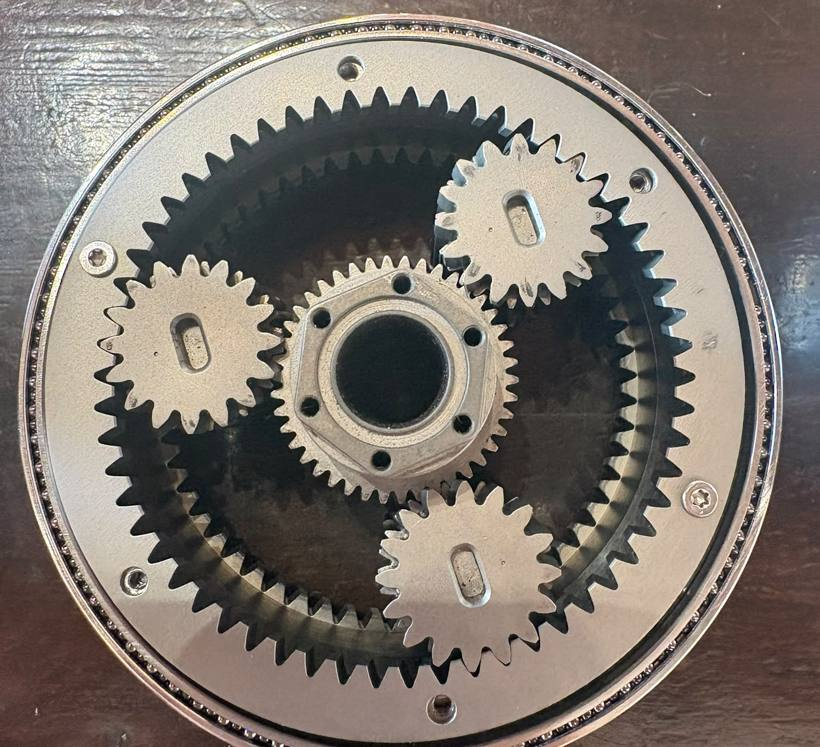

**Reducer, output face**Ring gear, compound planets and output sun on an early three-planet build. RS90 uses six.

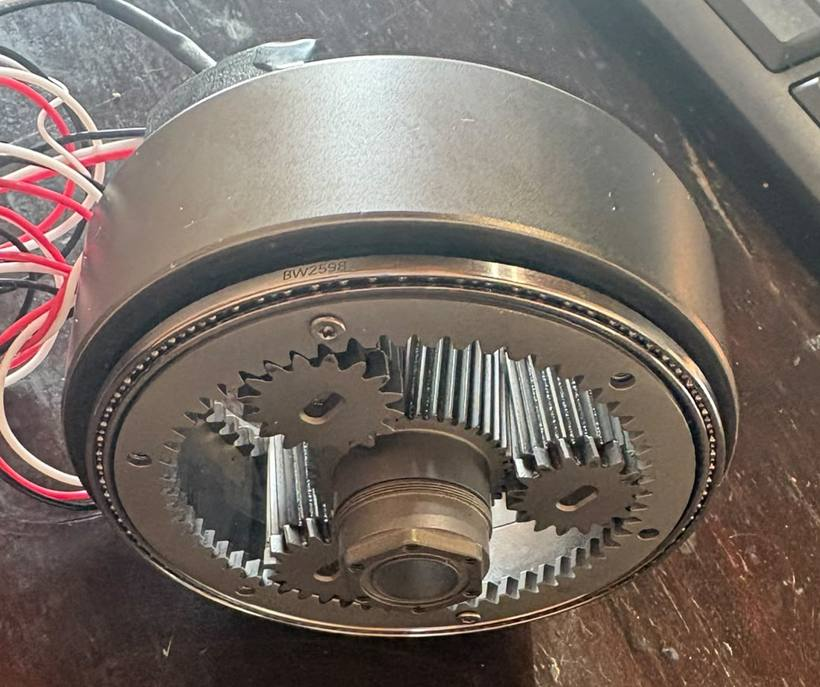

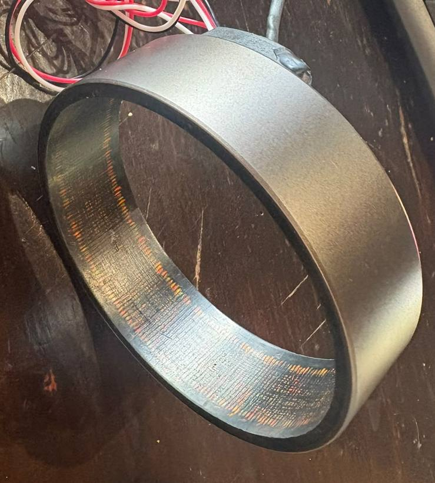

**Frameless stator**The only wired part. Everything else rotates inside it.

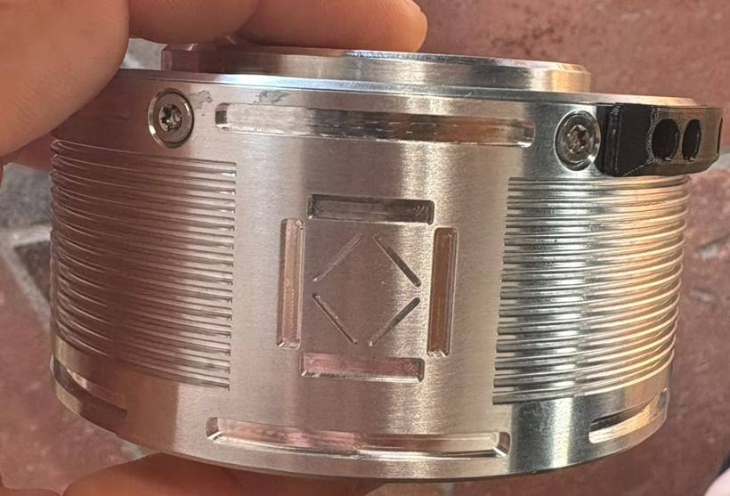

**Finned housing**Machined aluminium, cooling grooves, connector block.

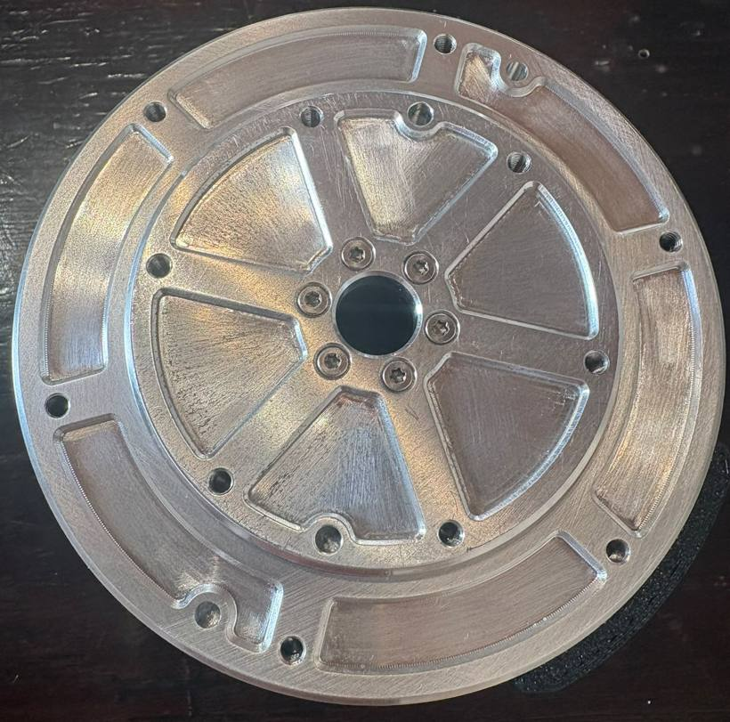

**Output flange**Pocketed to save mass, bolted to the output sun.

## RS90 at a glance

Preliminary specifications. Arm, knee and ankle joints on humanoids; hip, knee and ankle on quadrupeds.

Peak torque**120 Nm**

Nominal torque**24 Nm**

Peak torque density**114 Nm/kg**

Mass**1.05 kg**

Envelope**Ø90 × 51 mm**

Reduction**17.4 : 1***single stage, reversing*

Max output speed**~100 rpm**

Reducer efficiency**>90%***target, steel version*

Planets**6***carrierless, helical*

Motor**Frameless***inrunner, integrated driver*

Through-bore**Yes***cables, sensors, shaft*

Output**Both faces***double coupling shaft*

**RS60**

Neck, head and wrist. In development.

**RS90**

Elbow, knee, ankle. The actuator on this page.

**RS120**

Hip, shoulder, torso. 280 Nm peak class. In development.